# Risk Factor Analysis

## Outcome Variable

**Outcome Variable:** stunted

## Predictor Variables

**Intervention Variable:** gagebrth

**Adjustment Set:**

unadjusted

## Stratifying Variables

The analysis was stratified on these variable(s):

- agecat
- studyid
- country

## Data Summary

| agecat | studyid | country | A | n | nA | nAY0 | nAY1 |
| --- | --- | --- | --- | --- | --- | --- | --- |
| Birth | ki1000108-CMC-V-BCS-2002 | INDIA | [273-287) | 90 | 35 | 28 | 7 |
| Birth | ki1000108-CMC-V-BCS-2002 | INDIA | <259 | 90 | 7 | 6 | 1 |
| Birth | ki1000108-CMC-V-BCS-2002 | INDIA | [259-273) | 90 | 22 | 19 | 3 |
| Birth | ki1000108-CMC-V-BCS-2002 | INDIA | >=287 | 90 | 26 | 21 | 5 |
| Birth | ki1000108-IRC | INDIA | [273-287) | 369 | 155 | 141 | 14 |
| Birth | ki1000108-IRC | INDIA | <259 | 369 | 36 | 27 | 9 |
| Birth | ki1000108-IRC | INDIA | [259-273) | 369 | 87 | 80 | 7 |
| Birth | ki1000108-IRC | INDIA | >=287 | 369 | 91 | 77 | 14 |
| Birth | ki1000109-EE | PAKISTAN | [273-287) | 2 | 0 | 0 | 0 |
| Birth | ki1000109-EE | PAKISTAN | <259 | 2 | 1 | 0 | 1 |
| Birth | ki1000109-EE | PAKISTAN | [259-273) | 2 | 1 | 1 | 0 |
| Birth | ki1000109-EE | PAKISTAN | >=287 | 2 | 0 | 0 | 0 |
| Birth | ki1000304b-SAS-CompFeed | INDIA | [273-287) | 70 | 0 | 0 | 0 |
| Birth | ki1000304b-SAS-CompFeed | INDIA | <259 | 70 | 55 | 41 | 14 |
| Birth | ki1000304b-SAS-CompFeed | INDIA | [259-273) | 70 | 15 | 12 | 3 |
| Birth | ki1000304b-SAS-CompFeed | INDIA | >=287 | 70 | 0 | 0 | 0 |
| Birth | ki1017093c-NIH-Crypto | BANGLADESH | [273-287) | 27 | 12 | 10 | 2 |
| Birth | ki1017093c-NIH-Crypto | BANGLADESH | <259 | 27 | 3 | 1 | 2 |
| Birth | ki1017093c-NIH-Crypto | BANGLADESH | [259-273) | 27 | 11 | 10 | 1 |
| Birth | ki1017093c-NIH-Crypto | BANGLADESH | >=287 | 27 | 1 | 1 | 0 |
| Birth | ki1101329-Keneba | GAMBIA | [273-287) | 1515 | 592 | 572 | 20 |
| Birth | ki1101329-Keneba | GAMBIA | <259 | 1515 | 161 | 133 | 28 |
| Birth | ki1101329-Keneba | GAMBIA | [259-273) | 1515 | 592 | 560 | 32 |
| Birth | ki1101329-Keneba | GAMBIA | >=287 | 1515 | 170 | 168 | 2 |
| Birth | ki1119695-PROBIT | BELARUS | [273-287) | 6779 | 4858 | 4852 | 6 |
| Birth | ki1119695-PROBIT | BELARUS | <259 | 6779 | 0 | 0 | 0 |
| Birth | ki1119695-PROBIT | BELARUS | [259-273) | 6779 | 1403 | 1388 | 15 |
| Birth | ki1119695-PROBIT | BELARUS | >=287 | 6779 | 518 | 518 | 0 |
| Birth | ki1135781-COHORTS | GUATEMALA | [273-287) | 290 | 114 | 110 | 4 |
| Birth | ki1135781-COHORTS | GUATEMALA | <259 | 290 | 49 | 44 | 5 |

[output cut: 306 more lines]

The following strata were considered:

- agecat: 12 months, studyid: ki1000108-CMC-V-BCS-2002, country: INDIA
- agecat: 12 months, studyid: ki1000108-IRC, country: INDIA
- agecat: 12 months, studyid: ki1000109-EE, country: PAKISTAN
- agecat: 12 months, studyid: ki1000304b-SAS-CompFeed, country: INDIA
- agecat: 12 months, studyid: ki1017093c-NIH-Crypto, country: BANGLADESH
- agecat: 12 months, studyid: ki1066203-TanzaniaChild2, country: TANZANIA, UNITED REPUBLIC OF
- agecat: 12 months, studyid: ki1101329-Keneba, country: GAMBIA
- agecat: 12 months, studyid: ki1113344-GMS-Nepal, country: NEPAL
- agecat: 12 months, studyid: ki1119695-PROBIT, country: BELARUS
- agecat: 12 months, studyid: ki1135781-COHORTS, country: GUATEMALA
- agecat: 12 months, studyid: ki1135781-COHORTS, country: INDIA
- agecat: 12 months, studyid: ki1135781-COHORTS, country: PHILIPPINES
- agecat: 12 months, studyid: kiGH5241-JiVitA-3, country: BANGLADESH
- agecat: 18 months, studyid: ki1000108-CMC-V-BCS-2002, country: INDIA
- agecat: 18 months, studyid: ki1000108-IRC, country: INDIA
- agecat: 18 months, studyid: ki1000109-EE, country: PAKISTAN
- agecat: 18 months, studyid: ki1000304b-SAS-CompFeed, country: INDIA
- agecat: 18 months, studyid: ki1017093c-NIH-Crypto, country: BANGLADESH
- agecat: 18 months, studyid: ki1066203-TanzaniaChild2, country: TANZANIA, UNITED REPUBLIC OF
- agecat: 18 months, studyid: ki1101329-Keneba, country: GAMBIA
- agecat: 18 months, studyid: ki1113344-GMS-Nepal, country: NEPAL
- agecat: 18 months, studyid: ki1119695-PROBIT, country: BELARUS
- agecat: 18 months, studyid: ki1135781-COHORTS, country: GUATEMALA
- agecat: 18 months, studyid: ki1135781-COHORTS, country: PHILIPPINES
- agecat: 24 months, studyid: ki1000108-CMC-V-BCS-2002, country: INDIA
- agecat: 24 months, studyid: ki1000108-IRC, country: INDIA
- agecat: 24 months, studyid: ki1017093c-NIH-Crypto, country: BANGLADESH
- agecat: 24 months, studyid: ki1066203-TanzaniaChild2, country: TANZANIA, UNITED REPUBLIC OF
- agecat: 24 months, studyid: ki1101329-Keneba, country: GAMBIA
- agecat: 24 months, studyid: ki1113344-GMS-Nepal, country: NEPAL
- agecat: 24 months, studyid: ki1119695-PROBIT, country: BELARUS
- agecat: 24 months, studyid: ki1135781-COHORTS, country: GUATEMALA
- agecat: 24 months, studyid: ki1135781-COHORTS, country: INDIA
- agecat: 24 months, studyid: ki1135781-COHORTS, country: PHILIPPINES
- agecat: 24 months, studyid: kiGH5241-JiVitA-3, country: BANGLADESH
- agecat: 3 months, studyid: ki1000108-CMC-V-BCS-2002, country: INDIA
- agecat: 3 months, studyid: ki1000108-IRC, country: INDIA
- agecat: 3 months, studyid: ki1000109-EE, country: PAKISTAN
- agecat: 3 months, studyid: ki1000304b-SAS-CompFeed, country: INDIA
- agecat: 3 months, studyid: ki1017093c-NIH-Crypto, country: BANGLADESH
- agecat: 3 months, studyid: ki1066203-TanzaniaChild2, country: TANZANIA, UNITED REPUBLIC OF
- agecat: 3 months, studyid: ki1101329-Keneba, country: GAMBIA
- agecat: 3 months, studyid: ki1113344-GMS-Nepal, country: NEPAL
- agecat: 3 months, studyid: ki1119695-PROBIT, country: BELARUS
- agecat: 3 months, studyid: ki1135781-COHORTS, country: GUATEMALA
- agecat: 3 months, studyid: ki1135781-COHORTS, country: INDIA
- agecat: 3 months, studyid: ki1135781-COHORTS, country: PHILIPPINES
- agecat: 3 months, studyid: kiGH5241-JiVitA-3, country: BANGLADESH
- agecat: 6 months, studyid: ki1000108-CMC-V-BCS-2002, country: INDIA
- agecat: 6 months, studyid: ki1000108-IRC, country: INDIA
- agecat: 6 months, studyid: ki1000109-EE, country: PAKISTAN
- agecat: 6 months, studyid: ki1000304b-SAS-CompFeed, country: INDIA
- agecat: 6 months, studyid: ki1017093c-NIH-Crypto, country: BANGLADESH
- agecat: 6 months, studyid: ki1066203-TanzaniaChild2, country: TANZANIA, UNITED REPUBLIC OF
- agecat: 6 months, studyid: ki1101329-Keneba, country: GAMBIA
- agecat: 6 months, studyid: ki1113344-GMS-Nepal, country: NEPAL
- agecat: 6 months, studyid: ki1119695-PROBIT, country: BELARUS
- agecat: 6 months, studyid: ki1135781-COHORTS, country: GUATEMALA
- agecat: 6 months, studyid: ki1135781-COHORTS, country: INDIA
- agecat: 6 months, studyid: ki1135781-COHORTS, country: PHILIPPINES
- agecat: 6 months, studyid: kiGH5241-JiVitA-3, country: BANGLADESH
- agecat: 9 months, studyid: ki1000108-CMC-V-BCS-2002, country: INDIA
- agecat: 9 months, studyid: ki1000108-IRC, country: INDIA
- agecat: 9 months, studyid: ki1000109-EE, country: PAKISTAN
- agecat: 9 months, studyid: ki1000304b-SAS-CompFeed, country: INDIA
- agecat: 9 months, studyid: ki1017093c-NIH-Crypto, country: BANGLADESH
- agecat: 9 months, studyid: ki1066203-TanzaniaChild2, country: TANZANIA, UNITED REPUBLIC OF
- agecat: 9 months, studyid: ki1101329-Keneba, country: GAMBIA
- agecat: 9 months, studyid: ki1113344-GMS-Nepal, country: NEPAL
- agecat: 9 months, studyid: ki1119695-PROBIT, country: BELARUS
- agecat: 9 months, studyid: ki1135781-COHORTS, country: GUATEMALA
- agecat: 9 months, studyid: ki1135781-COHORTS, country: INDIA
- agecat: 9 months, studyid: ki1135781-COHORTS, country: PHILIPPINES
- agecat: Birth, studyid: ki1000108-CMC-V-BCS-2002, country: INDIA
- agecat: Birth, studyid: ki1000108-IRC, country: INDIA
- agecat: Birth, studyid: ki1000109-EE, country: PAKISTAN
- agecat: Birth, studyid: ki1000304b-SAS-CompFeed, country: INDIA
- agecat: Birth, studyid: ki1017093c-NIH-Crypto, country: BANGLADESH
- agecat: Birth, studyid: ki1101329-Keneba, country: GAMBIA
- agecat: Birth, studyid: ki1119695-PROBIT, country: BELARUS
- agecat: Birth, studyid: ki1135781-COHORTS, country: GUATEMALA
- agecat: Birth, studyid: ki1135781-COHORTS, country: INDIA
- agecat: Birth, studyid: ki1135781-COHORTS, country: PHILIPPINES
- agecat: Birth, studyid: kiGH5241-JiVitA-3, country: BANGLADESH

### Dropped Strata

Some strata were dropped due to rare outcomes:

- agecat: Birth, studyid: ki1000108-CMC-V-BCS-2002, country: INDIA
- agecat: Birth, studyid: ki1000109-EE, country: PAKISTAN
- agecat: Birth, studyid: ki1000304b-SAS-CompFeed, country: INDIA
- agecat: Birth, studyid: ki1017093c-NIH-Crypto, country: BANGLADESH
- agecat: Birth, studyid: ki1101329-Keneba, country: GAMBIA
- agecat: Birth, studyid: ki1119695-PROBIT, country: BELARUS
- agecat: Birth, studyid: ki1135781-COHORTS, country: GUATEMALA
- agecat: 3 months, studyid: ki1000109-EE, country: PAKISTAN
- agecat: 3 months, studyid: ki1000304b-SAS-CompFeed, country: INDIA
- agecat: 3 months, studyid: ki1017093c-NIH-Crypto, country: BANGLADESH
- agecat: 3 months, studyid: ki1113344-GMS-Nepal, country: NEPAL
- agecat: 3 months, studyid: ki1119695-PROBIT, country: BELARUS
- agecat: 6 months, studyid: ki1000109-EE, country: PAKISTAN
- agecat: 6 months, studyid: ki1000304b-SAS-CompFeed, country: INDIA
- agecat: 6 months, studyid: ki1017093c-NIH-Crypto, country: BANGLADESH
- agecat: 6 months, studyid: ki1113344-GMS-Nepal, country: NEPAL
- agecat: 6 months, studyid: ki1119695-PROBIT, country: BELARUS
- agecat: 9 months, studyid: ki1000109-EE, country: PAKISTAN
- agecat: 9 months, studyid: ki1000304b-SAS-CompFeed, country: INDIA
- agecat: 9 months, studyid: ki1017093c-NIH-Crypto, country: BANGLADESH
- agecat: 9 months, studyid: ki1113344-GMS-Nepal, country: NEPAL
- agecat: 9 months, studyid: ki1119695-PROBIT, country: BELARUS
- agecat: 12 months, studyid: ki1000109-EE, country: PAKISTAN
- agecat: 12 months, studyid: ki1000304b-SAS-CompFeed, country: INDIA
- agecat: 12 months, studyid: ki1017093c-NIH-Crypto, country: BANGLADESH
- agecat: 12 months, studyid: ki1113344-GMS-Nepal, country: NEPAL
- agecat: 12 months, studyid: ki1119695-PROBIT, country: BELARUS
- agecat: 18 months, studyid: ki1000109-EE, country: PAKISTAN
- agecat: 18 months, studyid: ki1000304b-SAS-CompFeed, country: INDIA
- agecat: 18 months, studyid: ki1017093c-NIH-Crypto, country: BANGLADESH
- agecat: 18 months, studyid: ki1113344-GMS-Nepal, country: NEPAL
- agecat: 18 months, studyid: ki1119695-PROBIT, country: BELARUS
- agecat: 24 months, studyid: ki1017093c-NIH-Crypto, country: BANGLADESH
- agecat: 24 months, studyid: ki1066203-TanzaniaChild2, country: TANZANIA, UNITED REPUBLIC OF
- agecat: 24 months, studyid: ki1113344-GMS-Nepal, country: NEPAL
- agecat: 24 months, studyid: ki1119695-PROBIT, country: BELARUS

## Methods Detail

We’re interested in the causal parameters $E[Y_a]$ for all values of $a \in \mathcal{A}$. These parameters represent the mean outcome if, possibly contrary to fact, we intervened to set all units to have $A=a$. Under the randomization and positivity assumptions, these are identified by the statistical parameters $\psi_a=E_W[E_{Y|A,W}(Y|A=a,W)]$. In addition, we’re interested in the mean of $Y$, $E[Y]$ under no intervention (the observed mean). We will estimate these parameters by using SuperLearner to fit the relevant likelihood factors – $E_{Y|A,W}(Y|A=a,W)$ and $p(A=a|W)$, and then updating our likelihood fit using a joint TMLE.

For unadjusted analyses ($W=\{\}$), initial likelihoods were estimated using Lrnr_glm to estimate the simple $E(Y|A)$ and Lrnr_mean to estimate $p(A)$. For adjusted analyses, a small library containing Lrnr_glmnet, Lrnr_xgboost, and Lrnr_mean was used.

Having estimated these parameters, we will then use the delta method to estimate relative risks and attributable risks relative to a prespecified baseline level of $A$.

# Results Detail

## Results Plots

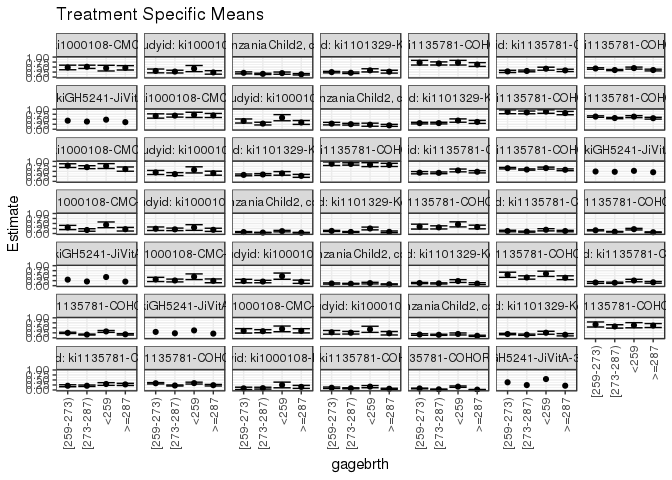

[figure not shown]

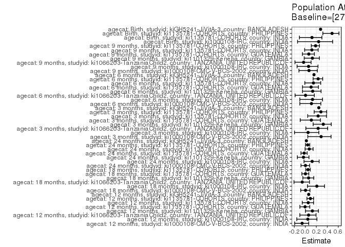

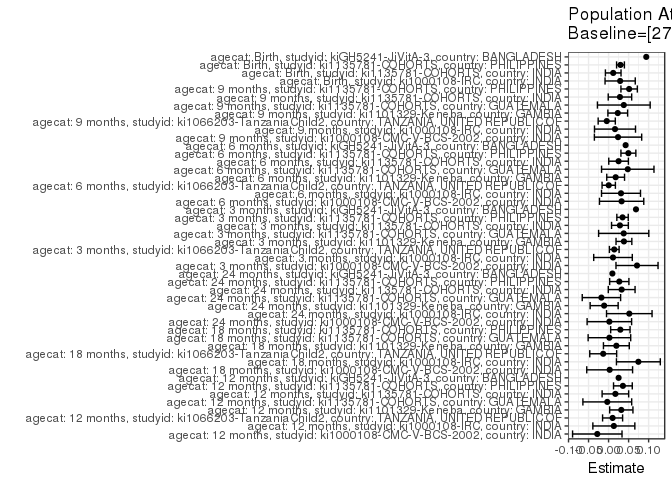

## Results Table

### Parameter: TSM

| agecat | studyid | country | intervention_level | baseline_level | estimate | ci_lower | ci_upper |
| --- | --- | --- | --- | --- | --- | --- | --- |
| Birth | ki1000108-IRC | INDIA | [273-287) | NA | 0.0903226 | 0.0451356 | 0.1355096 |
| Birth | ki1000108-IRC | INDIA | <259 | NA | 0.2500000 | 0.1083597 | 0.3916403 |
| Birth | ki1000108-IRC | INDIA | [259-273) | NA | 0.0804598 | 0.0232260 | 0.1376936 |
| Birth | ki1000108-IRC | INDIA | >=287 | NA | 0.1538462 | 0.0796153 | 0.2280770 |
| Birth | ki1135781-COHORTS | INDIA | [273-287) | NA | 0.0843137 | 0.0601895 | 0.1084380 |
| Birth | ki1135781-COHORTS | INDIA | <259 | NA | 0.1657459 | 0.1115523 | 0.2199394 |
| Birth | ki1135781-COHORTS | INDIA | [259-273) | NA | 0.1107266 | 0.0745348 | 0.1469185 |
| Birth | ki1135781-COHORTS | INDIA | >=287 | NA | 0.0607029 | 0.0342392 | 0.0871665 |
| Birth | ki1135781-COHORTS | PHILIPPINES | [273-287) | NA | 0.0314092 | 0.0214472 | 0.0413711 |
| Birth | ki1135781-COHORTS | PHILIPPINES | <259 | NA | 0.1655773 | 0.1315673 | 0.1995874 |
| Birth | ki1135781-COHORTS | PHILIPPINES | [259-273) | NA | 0.0756303 | 0.0576718 | 0.0935887 |
| Birth | ki1135781-COHORTS | PHILIPPINES | >=287 | NA | 0.0162455 | 0.0057168 | 0.0267742 |
| Birth | kiGH5241-JiVitA-3 | BANGLADESH | [273-287) | NA | 0.2447044 | NA | NA |
| Birth | kiGH5241-JiVitA-3 | BANGLADESH | <259 | NA | 0.5450311 | NA | NA |
| Birth | kiGH5241-JiVitA-3 | BANGLADESH | [259-273) | NA | 0.3824979 | NA | NA |
| Birth | kiGH5241-JiVitA-3 | BANGLADESH | >=287 | NA | 0.2128954 | NA | NA |
| 3 months | ki1000108-CMC-V-BCS-2002 | INDIA | [273-287) | NA | 0.1760563 | 0.1133202 | 0.2387925 |
| 3 months | ki1000108-CMC-V-BCS-2002 | INDIA | <259 | NA | 0.4347826 | 0.2913154 | 0.5782498 |
| 3 months | ki1000108-CMC-V-BCS-2002 | INDIA | [259-273) | NA | 0.3013699 | 0.1959555 | 0.4067842 |
| 3 months | ki1000108-CMC-V-BCS-2002 | INDIA | >=287 | NA | 0.2151899 | 0.1244355 | 0.3059442 |
| 3 months | ki1000108-IRC | INDIA | [273-287) | NA | 0.2085890 | 0.1461346 | 0.2710433 |
| 3 months | ki1000108-IRC | INDIA | <259 | NA | 0.3000000 | 0.1578033 | 0.4421967 |
| 3 months | ki1000108-IRC | INDIA | [259-273) | NA | 0.2391304 | 0.1518557 | 0.3264052 |
| 3 months | ki1000108-IRC | INDIA | >=287 | NA | 0.1847826 | 0.1053711 | 0.2641941 |
| 3 months | ki1066203-TanzaniaChild2 | TANZANIA, UNITED REPUBLIC OF | [273-287) | NA | 0.0465394 | 0.0322738 | 0.0608049 |
| 3 months | ki1066203-TanzaniaChild2 | TANZANIA, UNITED REPUBLIC OF | <259 | NA | 0.1193548 | 0.0832564 | 0.1554533 |
| 3 months | ki1066203-TanzaniaChild2 | TANZANIA, UNITED REPUBLIC OF | [259-273) | NA | 0.0720524 | 0.0483658 | 0.0957390 |
| 3 months | ki1066203-TanzaniaChild2 | TANZANIA, UNITED REPUBLIC OF | >=287 | NA | 0.0399274 | 0.0235758 | 0.0562790 |
| 3 months | ki1101329-Keneba | GAMBIA | [273-287) | NA | 0.0788530 | 0.0564836 | 0.1012225 |
| 3 months | ki1101329-Keneba | GAMBIA | <259 | NA | 0.2516556 | 0.1824145 | 0.3208968 |

[output cut: 162 more lines]

### Parameter: E(Y)

| agecat | studyid | country | intervention_level | baseline_level | estimate | ci_lower | ci_upper |
| --- | --- | --- | --- | --- | --- | --- | --- |
| Birth | ki1000108-IRC | INDIA | NA | NA | 0.1192412 | 0.0861307 | 0.1523517 |
| Birth | ki1135781-COHORTS | INDIA | NA | NA | 0.0959010 | 0.0798450 | 0.1119570 |
| Birth | ki1135781-COHORTS | PHILIPPINES | NA | NA | 0.0611772 | 0.0526341 | 0.0697204 |
| Birth | kiGH5241-JiVitA-3 | BANGLADESH | NA | NA | 0.3388205 | NA | NA |
| 3 months | ki1000108-CMC-V-BCS-2002 | INDIA | NA | NA | 0.2470588 | 0.2011465 | 0.2929711 |
| 3 months | ki1000108-IRC | INDIA | NA | NA | 0.2196382 | 0.1783376 | 0.2609388 |
| 3 months | ki1066203-TanzaniaChild2 | TANZANIA, UNITED REPUBLIC OF | NA | NA | 0.0607325 | 0.0506509 | 0.0708141 |
| 3 months | ki1101329-Keneba | GAMBIA | NA | NA | 0.1171983 | 0.1005907 | 0.1338060 |
| 3 months | ki1135781-COHORTS | GUATEMALA | NA | NA | 0.3437500 | 0.2940621 | 0.3934379 |
| 3 months | ki1135781-COHORTS | INDIA | NA | NA | 0.1215304 | 0.1039834 | 0.1390773 |
| 3 months | ki1135781-COHORTS | PHILIPPINES | NA | NA | 0.1228070 | 0.1107550 | 0.1348591 |
| 3 months | kiGH5241-JiVitA-3 | BANGLADESH | NA | NA | 0.2786546 | NA | NA |
| 6 months | ki1000108-CMC-V-BCS-2002 | INDIA | NA | NA | 0.2910663 | 0.2432023 | 0.3389303 |
| 6 months | ki1000108-IRC | INDIA | NA | NA | 0.2371134 | 0.1947393 | 0.2794875 |
| 6 months | ki1066203-TanzaniaChild2 | TANZANIA, UNITED REPUBLIC OF | NA | NA | 0.0956385 | 0.0824215 | 0.1088554 |
| 6 months | ki1101329-Keneba | GAMBIA | NA | NA | 0.1317322 | 0.1138432 | 0.1496211 |
| 6 months | ki1135781-COHORTS | GUATEMALA | NA | NA | 0.4553314 | 0.4028579 | 0.5078049 |
| 6 months | ki1135781-COHORTS | INDIA | NA | NA | 0.1692073 | 0.1489117 | 0.1895030 |
| 6 months | ki1135781-COHORTS | PHILIPPINES | NA | NA | 0.2113882 | 0.1959475 | 0.2268289 |
| 6 months | kiGH5241-JiVitA-3 | BANGLADESH | NA | NA | 0.2695526 | NA | NA |
| 9 months | ki1000108-CMC-V-BCS-2002 | INDIA | NA | NA | 0.3546512 | 0.3040222 | 0.4052801 |
| 9 months | ki1000108-IRC | INDIA | NA | NA | 0.2706186 | 0.2263548 | 0.3148824 |
| 9 months | ki1066203-TanzaniaChild2 | TANZANIA, UNITED REPUBLIC OF | NA | NA | 0.1464286 | 0.1295181 | 0.1633390 |
| 9 months | ki1101329-Keneba | GAMBIA | NA | NA | 0.1779230 | 0.1577156 | 0.1981305 |
| 9 months | ki1135781-COHORTS | GUATEMALA | NA | NA | 0.6072508 | 0.5545602 | 0.6599413 |
| 9 months | ki1135781-COHORTS | INDIA | NA | NA | 0.2384937 | 0.2143212 | 0.2626662 |
| 9 months | ki1135781-COHORTS | PHILIPPINES | NA | NA | 0.2746191 | 0.2577528 | 0.2914854 |
| 12 months | ki1000108-CMC-V-BCS-2002 | INDIA | NA | NA | 0.4855491 | 0.4328107 | 0.5382875 |
| 12 months | ki1000108-IRC | INDIA | NA | NA | 0.2875648 | 0.2423523 | 0.3327772 |
| 12 months | ki1066203-TanzaniaChild2 | TANZANIA, UNITED REPUBLIC OF | NA | NA | 0.1703540 | 0.1503369 | 0.1903711 |
| 12 months | ki1101329-Keneba | GAMBIA | NA | NA | 0.2469231 | 0.2234730 | 0.2703731 |
| 12 months | ki1135781-COHORTS | GUATEMALA | NA | NA | 0.6779661 | 0.6292227 | 0.7267095 |
| 12 months | ki1135781-COHORTS | INDIA | NA | NA | 0.3223214 | 0.2949379 | 0.3497050 |
| 12 months | ki1135781-COHORTS | PHILIPPINES | NA | NA | 0.3874366 | 0.3685726 | 0.4063006 |
| 12 months | kiGH5241-JiVitA-3 | BANGLADESH | NA | NA | 0.4076655 | NA | NA |
| 18 months | ki1000108-CMC-V-BCS-2002 | INDIA | NA | NA | 0.6829971 | 0.6339683 | 0.7320259 |
| 18 months | ki1000108-IRC | INDIA | NA | NA | 0.3549223 | 0.3071264 | 0.4027182 |
| 18 months | ki1066203-TanzaniaChild2 | TANZANIA, UNITED REPUBLIC OF | NA | NA | 0.2386117 | 0.2110842 | 0.2661392 |
| 18 months | ki1101329-Keneba | GAMBIA | NA | NA | 0.3259032 | 0.3004242 | 0.3513821 |
| 18 months | ki1135781-COHORTS | GUATEMALA | NA | NA | 0.8428094 | 0.8014839 | 0.8841349 |
| 18 months | ki1135781-COHORTS | PHILIPPINES | NA | NA | 0.5876163 | 0.5682031 | 0.6070296 |
| 24 months | ki1000108-CMC-V-BCS-2002 | INDIA | NA | NA | 0.7114286 | 0.6638920 | 0.7589651 |
| 24 months | ki1000108-IRC | INDIA | NA | NA | 0.4153846 | 0.3664142 | 0.4643550 |
| 24 months | ki1101329-Keneba | GAMBIA | NA | NA | 0.3321799 | 0.3050172 | 0.3593427 |
| 24 months | ki1135781-COHORTS | GUATEMALA | NA | NA | 0.8531250 | 0.8142802 | 0.8919698 |
| 24 months | ki1135781-COHORTS | INDIA | NA | NA | 0.4579511 | 0.4309402 | 0.4849620 |
| 24 months | ki1135781-COHORTS | PHILIPPINES | NA | NA | 0.6175743 | 0.5982239 | 0.6369246 |
| 24 months | kiGH5241-JiVitA-3 | BANGLADESH | NA | NA | 0.4878882 | NA | NA |

### Parameter: RR

| agecat | studyid | country | intervention_level | baseline_level | estimate | ci_lower | ci_upper |
| --- | --- | --- | --- | --- | --- | --- | --- |
| Birth | ki1000108-IRC | INDIA | [273-287) | [273-287) | 1.0000000 | 1.0000000 | 1.0000000 |
| Birth | ki1000108-IRC | INDIA | <259 | [273-287) | 2.7678571 | 1.2998454 | 5.8938031 |
| Birth | ki1000108-IRC | INDIA | [259-273) | [273-287) | 0.8908046 | 0.3733368 | 2.1255147 |
| Birth | ki1000108-IRC | INDIA | >=287 | [273-287) | 1.7032967 | 0.8500311 | 3.4130745 |
| Birth | ki1135781-COHORTS | INDIA | [273-287) | [273-287) | 1.0000000 | 1.0000000 | 1.0000000 |
| Birth | ki1135781-COHORTS | INDIA | <259 | [273-287) | 1.9658229 | 1.2730663 | 3.0355526 |
| Birth | ki1135781-COHORTS | INDIA | [259-273) | [273-287) | 1.3132695 | 0.8505432 | 2.0277356 |
| Birth | ki1135781-COHORTS | INDIA | >=287 | [273-287) | 0.7199643 | 0.4274080 | 1.2127725 |
| Birth | ki1135781-COHORTS | PHILIPPINES | [273-287) | [273-287) | 1.0000000 | 1.0000000 | 1.0000000 |
| Birth | ki1135781-COHORTS | PHILIPPINES | <259 | [273-287) | 5.2716246 | 3.6127475 | 7.6922136 |
| Birth | ki1135781-COHORTS | PHILIPPINES | [259-273) | [273-287) | 2.4079037 | 1.6202038 | 3.5785622 |
| Birth | ki1135781-COHORTS | PHILIPPINES | >=287 | [273-287) | 0.5172213 | 0.2513696 | 1.0642408 |
| Birth | kiGH5241-JiVitA-3 | BANGLADESH | [273-287) | [273-287) | 1.0000000 | NA | NA |
| Birth | kiGH5241-JiVitA-3 | BANGLADESH | <259 | [273-287) | 2.2273039 | NA | NA |
| Birth | kiGH5241-JiVitA-3 | BANGLADESH | [259-273) | [273-287) | 1.5631021 | NA | NA |
| Birth | kiGH5241-JiVitA-3 | BANGLADESH | >=287 | [273-287) | 0.8700104 | NA | NA |
| 3 months | ki1000108-CMC-V-BCS-2002 | INDIA | [273-287) | [273-287) | 1.0000000 | 1.0000000 | 1.0000000 |
| 3 months | ki1000108-CMC-V-BCS-2002 | INDIA | <259 | [273-287) | 2.4695652 | 1.5195061 | 4.0136413 |
| 3 months | ki1000108-CMC-V-BCS-2002 | INDIA | [259-273) | [273-287) | 1.7117808 | 1.0389458 | 2.8203528 |
| 3 months | ki1000108-CMC-V-BCS-2002 | INDIA | >=287 | [273-287) | 1.2222785 | 0.7036948 | 2.1230293 |
| 3 months | ki1000108-IRC | INDIA | [273-287) | [273-287) | 1.0000000 | 1.0000000 | 1.0000000 |
| 3 months | ki1000108-IRC | INDIA | <259 | [273-287) | 1.4382353 | 0.8210097 | 2.5194840 |
| 3 months | ki1000108-IRC | INDIA | [259-273) | [273-287) | 1.1464194 | 0.7150336 | 1.8380641 |
| 3 months | ki1000108-IRC | INDIA | >=287 | [273-287) | 0.8858696 | 0.5246839 | 1.4956908 |
| 3 months | ki1066203-TanzaniaChild2 | TANZANIA, UNITED REPUBLIC OF | [273-287) | [273-287) | 1.0000000 | 1.0000000 | 1.0000000 |
| 3 months | ki1066203-TanzaniaChild2 | TANZANIA, UNITED REPUBLIC OF | <259 | [273-287) | 2.5645988 | 1.6672634 | 3.9448877 |
| 3 months | ki1066203-TanzaniaChild2 | TANZANIA, UNITED REPUBLIC OF | [259-273) | [273-287) | 1.5482029 | 0.9876949 | 2.4267941 |
| 3 months | ki1066203-TanzaniaChild2 | TANZANIA, UNITED REPUBLIC OF | >=287 | [273-287) | 0.8579274 | 0.5143874 | 1.4309050 |
| 3 months | ki1101329-Keneba | GAMBIA | [273-287) | [273-287) | 1.0000000 | 1.0000000 | 1.0000000 |
| 3 months | ki1101329-Keneba | GAMBIA | <259 | [273-287) | 3.1914509 | 2.1495930 | 4.7382732 |

[output cut: 162 more lines]

### Parameter: PAR

| agecat | studyid | country | intervention_level | baseline_level | estimate | ci_lower | ci_upper |
| --- | --- | --- | --- | --- | --- | --- | --- |
| Birth | ki1000108-IRC | INDIA | [273-287) | NA | 0.0289186 | -0.0088012 | 0.0666384 |
| Birth | ki1135781-COHORTS | INDIA | [273-287) | NA | 0.0115873 | -0.0079235 | 0.0310981 |
| Birth | ki1135781-COHORTS | PHILIPPINES | [273-287) | NA | 0.0297681 | 0.0200261 | 0.0395101 |
| Birth | kiGH5241-JiVitA-3 | BANGLADESH | [273-287) | NA | 0.0941161 | NA | NA |
| 3 months | ki1000108-CMC-V-BCS-2002 | INDIA | [273-287) | NA | 0.0710025 | 0.0185030 | 0.1235019 |
| 3 months | ki1000108-IRC | INDIA | [273-287) | NA | 0.0110493 | -0.0371229 | 0.0592214 |
| 3 months | ki1066203-TanzaniaChild2 | TANZANIA, UNITED REPUBLIC OF | [273-287) | NA | 0.0141931 | 0.0020680 | 0.0263183 |
| 3 months | ki1101329-Keneba | GAMBIA | [273-287) | NA | 0.0383453 | 0.0186237 | 0.0580669 |
| 3 months | ki1135781-COHORTS | GUATEMALA | [273-287) | NA | 0.0377799 | -0.0248760 | 0.1004357 |
| 3 months | ki1135781-COHORTS | INDIA | [273-287) | NA | 0.0283745 | 0.0074449 | 0.0493041 |
| 3 months | ki1135781-COHORTS | PHILIPPINES | [273-287) | NA | 0.0348852 | 0.0206487 | 0.0491216 |
| 3 months | kiGH5241-JiVitA-3 | BANGLADESH | [273-287) | NA | 0.0684238 | NA | NA |
| 6 months | ki1000108-CMC-V-BCS-2002 | INDIA | [273-287) | NA | 0.0325629 | -0.0227385 | 0.0878642 |
| 6 months | ki1000108-IRC | INDIA | [273-287) | NA | 0.0310528 | -0.0175929 | 0.0796985 |
| 6 months | ki1066203-TanzaniaChild2 | TANZANIA, UNITED REPUBLIC OF | [273-287) | NA | 0.0004004 | -0.0162493 | 0.0170501 |
| 6 months | ki1101329-Keneba | GAMBIA | [273-287) | NA | 0.0176637 | -0.0045422 | 0.0398696 |
| 6 months | ki1135781-COHORTS | GUATEMALA | [273-287) | NA | 0.0479240 | -0.0175153 | 0.1133634 |
| 6 months | ki1135781-COHORTS | INDIA | [273-287) | NA | 0.0249765 | 0.0004594 | 0.0494937 |
| 6 months | ki1135781-COHORTS | PHILIPPINES | [273-287) | NA | 0.0494834 | 0.0308580 | 0.0681088 |
| 6 months | kiGH5241-JiVitA-3 | BANGLADESH | [273-287) | NA | 0.0425531 | NA | NA |
| 9 months | ki1000108-CMC-V-BCS-2002 | INDIA | [273-287) | NA | 0.0236167 | -0.0354336 | 0.0826670 |
| 9 months | ki1000108-IRC | INDIA | [273-287) | NA | 0.0160731 | -0.0351262 | 0.0672724 |
| 9 months | ki1066203-TanzaniaChild2 | TANZANIA, UNITED REPUBLIC OF | [273-287) | NA | -0.0045730 | -0.0259881 | 0.0168422 |
| 9 months | ki1101329-Keneba | GAMBIA | [273-287) | NA | 0.0229415 | -0.0016754 | 0.0475583 |
| 9 months | ki1135781-COHORTS | GUATEMALA | [273-287) | NA | 0.0380200 | -0.0278225 | 0.1038625 |
| 9 months | ki1135781-COHORTS | INDIA | [273-287) | NA | 0.0284097 | -0.0008627 | 0.0576820 |
| 9 months | ki1135781-COHORTS | PHILIPPINES | [273-287) | NA | 0.0513457 | 0.0308600 | 0.0718314 |
| 12 months | ki1000108-CMC-V-BCS-2002 | INDIA | [273-287) | NA | -0.0281495 | -0.0898759 | 0.0335769 |
| 12 months | ki1000108-IRC | INDIA | [273-287) | NA | 0.0131745 | -0.0392348 | 0.0655839 |
| 12 months | ki1066203-TanzaniaChild2 | TANZANIA, UNITED REPUBLIC OF | [273-287) | NA | 0.0100486 | -0.0149512 | 0.0350485 |
| 12 months | ki1101329-Keneba | GAMBIA | [273-287) | NA | 0.0317836 | 0.0027261 | 0.0608412 |
| 12 months | ki1135781-COHORTS | GUATEMALA | [273-287) | NA | -0.0031933 | -0.0641176 | 0.0577310 |
| 12 months | ki1135781-COHORTS | INDIA | [273-287) | NA | 0.0170117 | -0.0161214 | 0.0501448 |
| 12 months | ki1135781-COHORTS | PHILIPPINES | [273-287) | NA | 0.0357882 | 0.0123909 | 0.0591856 |
| 12 months | kiGH5241-JiVitA-3 | BANGLADESH | [273-287) | NA | 0.0250659 | NA | NA |
| 18 months | ki1000108-CMC-V-BCS-2002 | INDIA | [273-287) | NA | 0.0027250 | -0.0544980 | 0.0599480 |
| 18 months | ki1000108-IRC | INDIA | [273-287) | NA | 0.0744345 | 0.0196933 | 0.1291756 |
| 18 months | ki1066203-TanzaniaChild2 | TANZANIA, UNITED REPUBLIC OF | [273-287) | NA | -0.0133990 | -0.0469959 | 0.0201978 |
| 18 months | ki1101329-Keneba | GAMBIA | [273-287) | NA | 0.0194515 | -0.0128043 | 0.0517074 |
| 18 months | ki1135781-COHORTS | GUATEMALA | [273-287) | NA | 0.0021014 | -0.0510307 | 0.0552335 |
| 18 months | ki1135781-COHORTS | PHILIPPINES | [273-287) | NA | 0.0294289 | 0.0052250 | 0.0536328 |
| 24 months | ki1000108-CMC-V-BCS-2002 | INDIA | [273-287) | NA | 0.0019691 | -0.0535966 | 0.0575348 |
| 24 months | ki1000108-IRC | INDIA | [273-287) | NA | 0.0517483 | -0.0050767 | 0.1085732 |
| 24 months | ki1101329-Keneba | GAMBIA | [273-287) | NA | -0.0110695 | -0.0460215 | 0.0238825 |
| 24 months | ki1135781-COHORTS | GUATEMALA | [273-287) | NA | -0.0178427 | -0.0657461 | 0.0300606 |
| 24 months | ki1135781-COHORTS | INDIA | [273-287) | NA | 0.0327084 | -0.0007186 | 0.0661353 |
| 24 months | ki1135781-COHORTS | PHILIPPINES | [273-287) | NA | 0.0267601 | 0.0027251 | 0.0507950 |
| 24 months | kiGH5241-JiVitA-3 | BANGLADESH | [273-287) | NA | 0.0095504 | NA | NA |

### Parameter: PAF

| agecat | studyid | country | intervention_level | baseline_level | estimate | ci_lower | ci_upper |
| --- | --- | --- | --- | --- | --- | --- | --- |
| Birth | ki1000108-IRC | INDIA | [273-287) | NA | 0.2425220 | -0.1414049 | 0.4973099 |
| Birth | ki1135781-COHORTS | INDIA | [273-287) | NA | 0.1208254 | -0.1070545 | 0.3017978 |
| Birth | ki1135781-COHORTS | PHILIPPINES | [273-287) | NA | 0.4865874 | 0.3189257 | 0.6129755 |
| Birth | kiGH5241-JiVitA-3 | BANGLADESH | [273-287) | NA | 0.2777756 | NA | NA |
| 3 months | ki1000108-CMC-V-BCS-2002 | INDIA | [273-287) | NA | 0.2873910 | 0.0446545 | 0.4684525 |
| 3 months | ki1000108-IRC | INDIA | [273-287) | NA | 0.0503067 | -0.1962919 | 0.2460726 |
| 3 months | ki1066203-TanzaniaChild2 | TANZANIA, UNITED REPUBLIC OF | [273-287) | NA | 0.2336989 | 0.0100634 | 0.4068132 |
| 3 months | ki1101329-Keneba | GAMBIA | [273-287) | NA | 0.3271829 | 0.1428129 | 0.4718973 |
| 3 months | ki1135781-COHORTS | GUATEMALA | [273-287) | NA | 0.1099050 | -0.0923136 | 0.2746872 |
| 3 months | ki1135781-COHORTS | INDIA | [273-287) | NA | 0.2334765 | 0.0436527 | 0.3856225 |
| 3 months | ki1135781-COHORTS | PHILIPPINES | [273-287) | NA | 0.2840650 | 0.1614089 | 0.3887808 |
| 3 months | kiGH5241-JiVitA-3 | BANGLADESH | [273-287) | NA | 0.2455506 | NA | NA |
| 6 months | ki1000108-CMC-V-BCS-2002 | INDIA | [273-287) | NA | 0.1118745 | -0.0996755 | 0.2827275 |
| 6 months | ki1000108-IRC | INDIA | [273-287) | NA | 0.1309618 | -0.0996579 | 0.3132160 |
| 6 months | ki1066203-TanzaniaChild2 | TANZANIA, UNITED REPUBLIC OF | [273-287) | NA | 0.0041863 | -0.1860470 | 0.1639075 |
| 6 months | ki1101329-Keneba | GAMBIA | [273-287) | NA | 0.1340882 | -0.0511242 | 0.2866654 |
| 6 months | ki1135781-COHORTS | GUATEMALA | [273-287) | NA | 0.1052508 | -0.0509510 | 0.2382365 |
| 6 months | ki1135781-COHORTS | INDIA | [273-287) | NA | 0.1476091 | -0.0094900 | 0.2802602 |
| 6 months | ki1135781-COHORTS | PHILIPPINES | [273-287) | NA | 0.2340879 | 0.1418123 | 0.3164416 |
| 6 months | kiGH5241-JiVitA-3 | BANGLADESH | [273-287) | NA | 0.1578656 | NA | NA |
| 9 months | ki1000108-CMC-V-BCS-2002 | INDIA | [273-287) | NA | 0.0665913 | -0.1156938 | 0.2190942 |
| 9 months | ki1000108-IRC | INDIA | [273-287) | NA | 0.0593939 | -0.1500775 | 0.2307129 |
| 9 months | ki1066203-TanzaniaChild2 | TANZANIA, UNITED REPUBLIC OF | [273-287) | NA | -0.0312300 | -0.1883254 | 0.1050975 |
| 9 months | ki1101329-Keneba | GAMBIA | [273-287) | NA | 0.1289404 | -0.0204432 | 0.2564556 |
| 9 months | ki1135781-COHORTS | GUATEMALA | [273-287) | NA | 0.0626100 | -0.0526268 | 0.1652312 |
| 9 months | ki1135781-COHORTS | INDIA | [273-287) | NA | 0.1191213 | -0.0122732 | 0.2334607 |
| 9 months | ki1135781-COHORTS | PHILIPPINES | [273-287) | NA | 0.1869706 | 0.1092176 | 0.2579368 |
| 12 months | ki1000108-CMC-V-BCS-2002 | INDIA | [273-287) | NA | -0.0579746 | -0.1932299 | 0.0619493 |
| 12 months | ki1000108-IRC | INDIA | [273-287) | NA | 0.0458141 | -0.1549672 | 0.2116913 |
| 12 months | ki1066203-TanzaniaChild2 | TANZANIA, UNITED REPUBLIC OF | [273-287) | NA | 0.0589868 | -0.0997101 | 0.1947825 |
| 12 months | ki1101329-Keneba | GAMBIA | [273-287) | NA | 0.1287188 | 0.0030349 | 0.2385581 |
| 12 months | ki1135781-COHORTS | GUATEMALA | [273-287) | NA | -0.0047101 | -0.0987171 | 0.0812535 |
| 12 months | ki1135781-COHORTS | INDIA | [273-287) | NA | 0.0527787 | -0.0557911 | 0.1501839 |
| 12 months | ki1135781-COHORTS | PHILIPPINES | [273-287) | NA | 0.0923719 | 0.0299007 | 0.1508201 |
| 12 months | kiGH5241-JiVitA-3 | BANGLADESH | [273-287) | NA | 0.0614865 | NA | NA |
| 18 months | ki1000108-CMC-V-BCS-2002 | INDIA | [273-287) | NA | 0.0039898 | -0.0834188 | 0.0843464 |
| 18 months | ki1000108-IRC | INDIA | [273-287) | NA | 0.2097205 | 0.0398171 | 0.3495597 |
| 18 months | ki1066203-TanzaniaChild2 | TANZANIA, UNITED REPUBLIC OF | [273-287) | NA | -0.0561540 | -0.2067147 | 0.0756213 |
| 18 months | ki1101329-Keneba | GAMBIA | [273-287) | NA | 0.0596850 | -0.0446741 | 0.1536190 |
| 18 months | ki1135781-COHORTS | GUATEMALA | [273-287) | NA | 0.0024933 | -0.0625843 | 0.0635853 |
| 18 months | ki1135781-COHORTS | PHILIPPINES | [273-287) | NA | 0.0500819 | 0.0079266 | 0.0904458 |
| 24 months | ki1000108-CMC-V-BCS-2002 | INDIA | [273-287) | NA | 0.0027678 | -0.0784775 | 0.0778927 |
| 24 months | ki1000108-IRC | INDIA | [273-287) | NA | 0.1245791 | -0.0237145 | 0.2513911 |
| 24 months | ki1101329-Keneba | GAMBIA | [273-287) | NA | -0.0333238 | -0.1440887 | 0.0667174 |
| 24 months | ki1135781-COHORTS | GUATEMALA | [273-287) | NA | -0.0209146 | -0.0787304 | 0.0338026 |
| 24 months | ki1135781-COHORTS | INDIA | [273-287) | NA | 0.0714232 | -0.0045896 | 0.1416845 |
| 24 months | ki1135781-COHORTS | PHILIPPINES | [273-287) | NA | 0.0433309 | 0.0035586 | 0.0815157 |
| 24 months | kiGH5241-JiVitA-3 | BANGLADESH | [273-287) | NA | 0.0195751 | NA | NA |